# Homework 4

Małgorzata Pujszo

Tuesday, October 27, 2015

Rozpatruję 2 zmienne jakościowe: A i B. Jedna rozmiaru k=3, druga m=4. Zakładam, że w każdej z grup jest n=100 obserwacji. Ustalam średnią mi, tworzę wektory alpha, beta i macierz gamma - efekty addytywne pierwszej i drugiej zmiennej oraz efekty interakcji. Niektóre współrzędne ustalam na wartość 0.7.

```r
library(ggplot2)

n <- 100
alpha <- c(0.7, 0, 0)
beta <- c(0, 0.7, 0.7, 0)

k <- length(alpha)
m <- length(beta)

gamma <- matrix(0, nrow=k, ncol=m)
gamma[2,2] <- 0.7
gamma[2,4] <- 0.7
gamma[3,3] <- 0.7

mi <- 0

A <- rep(1:k, each=n*m)
B <-rep(1:m, times=n*k)
```

Ponieważ chcemy badać moc testów (prawdopodobieństwo odrzucenia hipotezy zerowej pod warunkiem, że wiemy, że prawdziwa jest hipoteza alternatywna) dla efektów głównych i dla efektu interakcji w trzech scenariuszach, tworzę funkcję trzech parametrów binarnych (czy.alpha, czy.beta, czy.gamma). Funkcja buduje model w zależności od tych parametrów i zwraca wyniki dwukierunkowej ANOVY zbudowanej na tym modelu. Dwukierunkowa ANOVA zwróci nam odpowiednie p-wartości dla interesujących nas testów.

```r
f <- function(czy.alpha, czy.beta, czy.gamma) {
  y <- mi + czy.alpha*alpha[A] + czy.beta*beta[B] + czy.gamma*gamma[cbind(A,B)] + rnorm(n*m*k)
  df <- data.frame(y=y, A=factor(A), B=factor(B))
  return (anova(lm(y~A*B, data=df)))
}
```

By dostać moce testów musimy tę funkcję zreplikować wiele razy (w tym przypadku będzie to 1000).

1. Scenariusz - pewne efekty główne przyjmują wartość 0.7

Istotność cechy A:

```r
set.seed(3)
istot.A <- replicate (1000, f(1, 1, 0)[1,5])
istotnosc.A <- data.frame(p=istot.A)
ggplot(istotnosc.A, aes(x=p)) +
  geom_histogram() +
  xlim(0,1) +
  ggtitle(paste0(round(100*mean(istot.A < 0.05),1), "% p-wartości mniejszych niż 0.05 \n\n",
                 round(100*mean(istot.A >= 0.05),1), "% p-wartości większych niż 0.05"))
```

[output not shown]

W tym przypadku 100% testów dobrze oceniło istotność efektów addytywnych cechy A (odrzuciło hipotezę zerową o braku istotności), więc moc tego testu wynosi 100%.

Istotność cechy B:

```r
set.seed(3)
istot.B <- replicate (1000, f(1, 1, 0)[2,5])
istotnosc.B <- data.frame(p=istot.B)
ggplot(istotnosc.B, aes(x=p)) +
  geom_histogram() +
  xlim(0,1) +
  ggtitle(paste0(round(100*mean(istot.B < 0.05),1), "% p-wartości mniejszych niż 0.05 \n\n",
                 round(100*mean(istot.B >= 0.05),1), "% p-wartości większych niż 0.05"))
```

[output not shown]

Tutaj podobnie moc testu wynosi 100%.

Istotność interakcji:

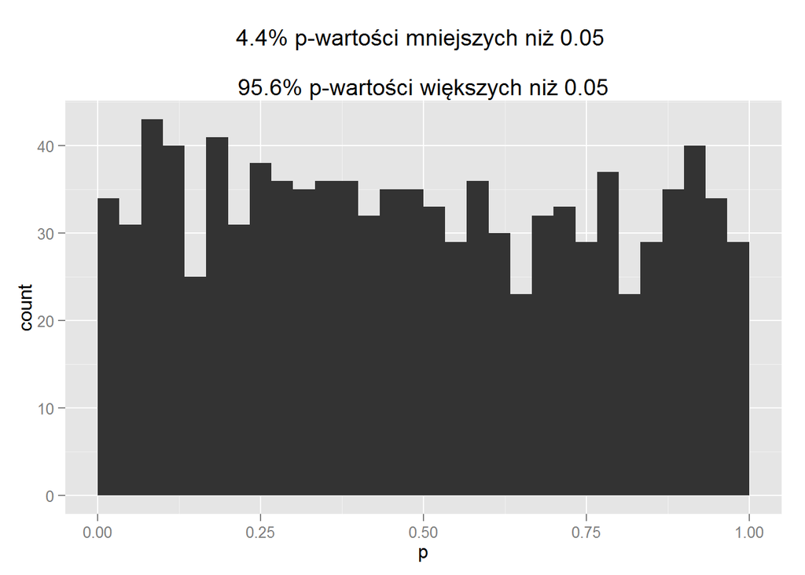

```r
set.seed(3)
istot.A.B <- replicate (1000, f(1, 1, 0)[3,5])
istotnosc.A.B <- data.frame(p=istot.A.B)
ggplot(istotnosc.A.B, aes(x=p)) +
  geom_histogram() +
  xlim(0,1) +
  ggtitle(paste0(round(100*mean(istot.A.B < 0.05),1), "% p-wartości mniejszych niż 0.05 \n\n",
                 round(100*mean(istot.A.B >= 0.05),1), "% p-wartości większych niż 0.05"))
```

W tym przypadku w 95,6% przypadków nasz test dobrze ocenił istotność interakcji, czyli przyjął hipotezę zerową o braku istotności efektów interakcji.

2. Scenariusz - pewne efekty interakcji przyjmują wartość 0.7.

Istotność cechy A:

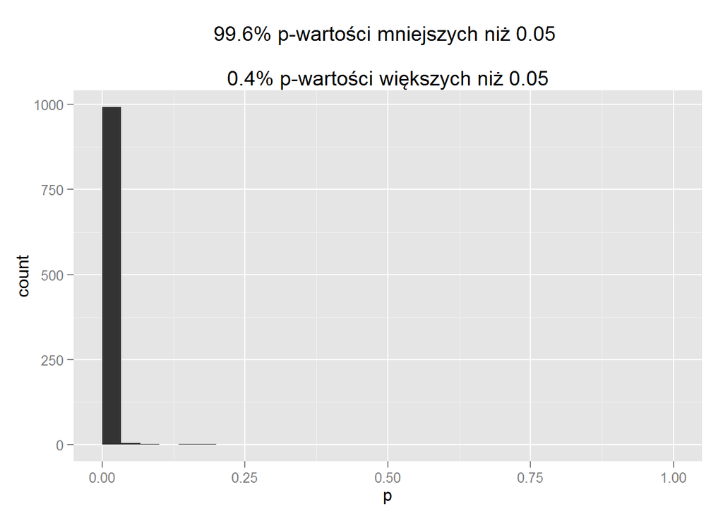

```r
set.seed(3)
istot.A <- replicate (1000, f(0, 0, 1)[1,5])
istotnosc.A <- data.frame(p=istot.A)
ggplot(istotnosc.A, aes(x=p)) +
  geom_histogram() +
  xlim(0,1) +
  ggtitle(paste0(round(100*mean(istot.A < 0.05),1), "% p-wartości mniejszych niż 0.05 \n\n",
                 round(100*mean(istot.A >= 0.05),1), "% p-wartości większych niż 0.05"))
```

W tym przypadku hipoteza zerowa o braku istotności efektów addytywnych cechy A jest prawdziwa. Jednak tylko 0,4% testów uznało ją za prawdziwą.

Istotność cechy B:

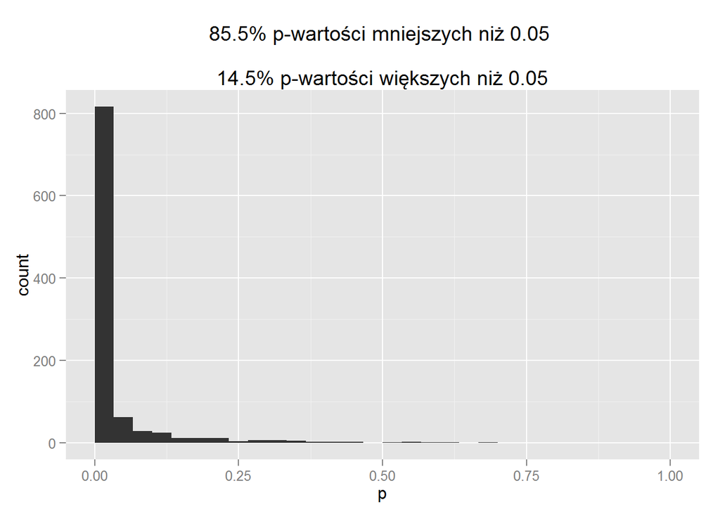

```r
set.seed(3)
istot.B <- replicate (1000, f(0, 0, 1)[2,5])
istotnosc.B <- data.frame(p=istot.B)
ggplot(istotnosc.B, aes(x=p)) +
  geom_histogram() +
  xlim(0,1) +
  ggtitle(paste0(round(100*mean(istot.B < 0.05),1), "% p-wartości mniejszych niż 0.05 \n\n",
                 round(100*mean(istot.B >= 0.05),1), "% p-wartości większych niż 0.05"))
```

Tutaj również tylko 14,5% nie odrzuca prawdziwej hipotezy zerowej o braku istotności cechy B.

Istotność interakcji:

```r
set.seed(3)
istot.A.B <- replicate (1000, f(0, 0, 1)[3,5])
istotnosc.A.B <- data.frame(p=istot.A.B)
ggplot(istotnosc.A.B, aes(x=p)) +
  geom_histogram() +
  xlim(0,1) +
  ggtitle(paste0(round(100*mean(istot.A.B < 0.05),1), "% p-wartości mniejszych niż 0.05 \n\n",
                 round(100*mean(istot.A.B >= 0.05),1), "% p-wartości większych niż 0.05"))
```

[output not shown]

W tym przypadku w 100% przypadków nasz test dobrze ocenił istotność interakcji (odrzucił nieprawdziwą hipotezę zerową o braku interakcji). Czyli moc testu wynosi 100%.

3. Scenariusz - pewne efekty główne i efekty interakcji przyjmują wartość 0.7.

Istotność cechy A:

```r
set.seed(3)
istot.A <- replicate (1000, f(1, 1, 1)[1,5])
istotnosc.A <- data.frame(p=istot.A)
ggplot(istotnosc.A, aes(x=p)) +
  geom_histogram() +
  xlim(0,1) +
  ggtitle(paste0(round(100*mean(istot.A < 0.05),1), "% p-wartości mniejszych niż 0.05 \n\n",
                 round(100*mean(istot.A >= 0.05),1), "% p-wartości większych niż 0.05"))
```

[output not shown]

W tym przypadku 100% testów dobrze oceniło istotność cechy A, więc moc tego testu wynosi 100%. Istotność cechy B:

```r
set.seed(3)
istot.B <- replicate (1000, f(1, 1, 1)[2,5])
istotnosc.B <- data.frame(p=istot.B)
ggplot(istotnosc.B, aes(x=p)) +
  geom_histogram() +
  xlim(0,1) +
  ggtitle(paste0(round(100*mean(istot.B < 0.05),1), "% p-wartości mniejszych niż 0.05 \n\n",
                 round(100*mean(istot.B >= 0.05),1), "% p-wartości większych niż 0.05"))
```

[output not shown]

Tutaj podobnie moc testu wynosi 100%.

Istotność interakcji:

```r
set.seed(3)
istot.A.B <- replicate (1000, f(1, 1, 1)[3,5])
istotnosc.A.B <- data.frame(p=istot.A.B)
ggplot(istotnosc.A.B, aes(x=p)) +
  geom_histogram() +
  xlim(0,1) +
  ggtitle(paste0(round(100*mean(istot.A.B < 0.05),1), "% p-wartości mniejszych niż 0.05 \n\n",
                 round(100*mean(istot.A.B >= 0.05),1), "% p-wartości większych niż 0.05"))
```

[output not shown]

W tym przypadku w 100% przypadków nasz test dobrze ocenił istotność interakcji. Czyli moc testu wynosi 100%.